# Introduction to Algorithm Analysis and Big O

## Breadth First Search

- Breadth first search (BFS) is one of the easiest algorithms for searching a graph. It also serves as a prototype for several other important graph algorithms that we will study later.
- Given a graph G and a starting vertex s, a breadth first search proceeds by exploring edges in the graph to find all the vertices in G for which there is a path from s.
- The remarkable thing about a breadth first search is that it finds all the vertices that are a distance k from s before it finds any vertices that are a distance k+1.
- One good way to visualize what the breadth first search algorithm does is to imagine that it is building a tree, one level of the tree at a time.
- A breadth first search adds all children of the starting vertex before it begins to discover any of the grandchildren.
- To keep track of its progress, BFS colors each of the vertices white, gray, or black.
- All the vertices are initialized to white when they are constructed.
- A white vertex is an undiscovered vertex.
- When a vertex is initially discovered it is colored gray, and when BFS has completely explored a vertex it is colored black.
- This means that once a vertex is colored black, it has no white vertices adjacent to it.
- A gray node, on the other hand, may have some white vertices adjacent to it, indicating that there are still additional vertices to explore.
- BFS begins at the starting vertex s and colors start gray to show that it is currently being explored.
- Two other values, the distance and the predecessor, are initialized to 0 and None respectively for the starting vertex.
- Finally, start is placed on a Queue.
- The next step is to begin to systematically explore vertices at the front of the queue.
- We explore each new node at the front of the queue by iterating over its adjacency list. As each node on the adjacency list is examined its color is checked.
- If it is white, the vertex is unexplored, and four things happen:
- If it is white, the vertex is unexplored, and four things happen:
  - The new, unexplored vertex nbr, is colored gray.
  - The predecessor of nbr is set to the current node currentVert
  - The distance to nbr is set to the distance to currentVert + 1
  - nbr is added to the end of a queue. Adding nbr to the end of the queue effectively schedules this node for further exploration, but not until all the other vertices on the adjacency list of currentVert have been explored.

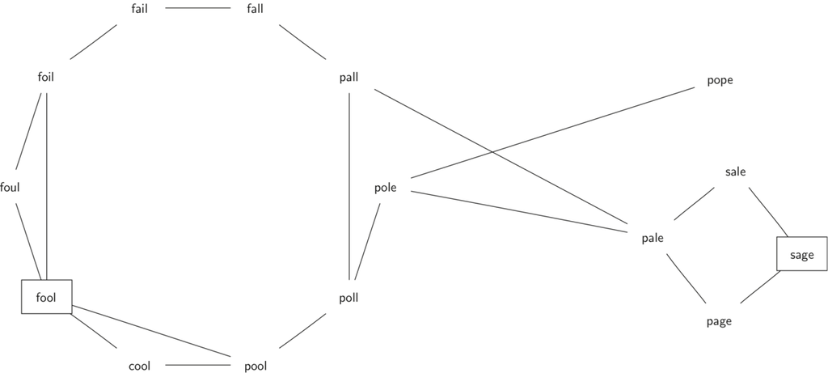

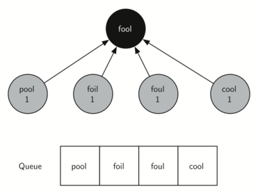

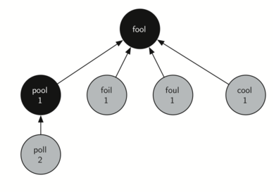

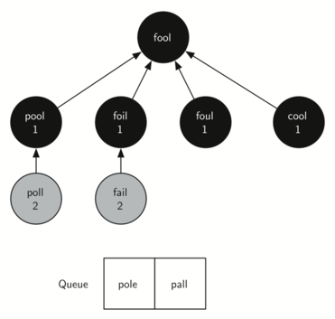

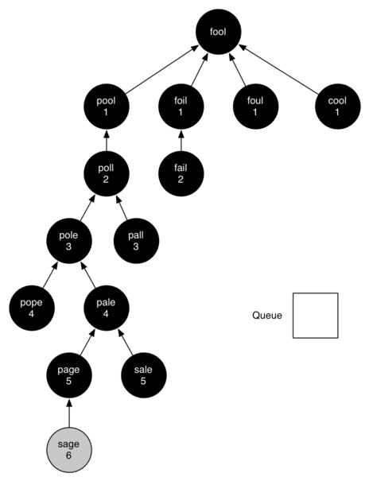

- The amazing thing about the breadth first search solution is that we have not only solved the FOOL–SAGE problem we started out with, but we have solved many other problems along the way.
- We can start at any vertex in the breadth first search tree and follow the predecessor arrows back to the root to find the shortest word ladder from any word back to fool.

### Implementation of Breadth First Search

An alternative algorithm called Breath-First search provides us with the ability to return the same results as DFS but with the added guarantee to return the shortest-path first. This algorithm is a little more tricky to implement in a recursive manner instead using the queue data-structure, as such I will only being documenting the iterative approach. The actions performed per each explored vertex are the same as the depth-first implementation, however, replacing the stack with a queue will instead explore the breadth of a vertex depth before moving on. This behavior guarantees that the first path located is one of the shortest-paths present, based on number of edges being the cost factor.

We'll assume our Graph is in the form:

```python
graph = {'A': set(['B', 'C']),
         'B': set(['A', 'D', 'E']),
         'C': set(['A', 'F']),
         'D': set(['B']),
         'E': set(['B', 'F']),
         'F': set(['C', 'E'])}
```

### Connected Component

Similar to the iterative DFS implementation the only alteration required is to remove the next item from the beginning of the list structure instead of the stacks last.

```python
def bfs(graph, start):
    visited, queue = set(), [start]
    while queue:
        vertex = queue.pop(0)
        if vertex not in visited:
            visited.add(vertex)
            queue.extend(graph[vertex] - visited)
    return visited

bfs(graph, 'A')
```

```
{'A', 'B', 'C', 'D', 'E', 'F'}
```

### Paths

This implementation can again be altered slightly to instead return all possible paths between two vertices, the first of which being one of the shortest such path.

```python
def bfs_paths(graph, start, goal):
    queue = [(start, [start])]
    while queue:
        (vertex, path) = queue.pop(0)
        for next in graph[vertex] - set(path):
            if next == goal:
                yield path + [next]
            else:
                queue.append((next, path + [next]))

list(bfs_paths(graph, 'A', 'F'))
```

```
[['A', 'C', 'F'], ['A', 'B', 'E', 'F']]
```

Knowing that the shortest path will be returned first from the BFS path generator method we can create a useful method which simply returns the shortest path found or ‘None’ if no path exists. As we are using a generator this in theory should provide similar performance results as just breaking out and returning the first matching path in the BFS implementation.

```python
def shortest_path(graph, start, goal):
    try:
        return next(bfs_paths(graph, start, goal))
    except StopIteration:
        return None

shortest_path(graph, 'A', 'F')
```

```
['A', 'C', 'F']
```

## Depth First Search

DFS

- The knight’s tour is a special case of a depth first search where the goal is to create the deepest depth first tree, without any branches.
- The more general depth first search is actually easier.
- Its goal is to search as deeply as possible, connecting as many nodes in the graph as possible and branching where necessary.
- It is even possible that a depth first search will create more than one tree.
- When the depth first search algorithm creates a group of trees we call this a depth first forest.
- As with the breadth first search our depth first search makes use of predecessor links to construct the tree.
- As with the breadth first search our depth first search makes use of predecessor links to construct the tree.
- In addition, the depth first search will make use of two additional instance variables in the Vertex class.
- The new instance variables are the discovery and finish times.
- The discovery time tracks the number of steps in the algorithm before a vertex is first encountered.
- The finish time is the number of steps in the algorithm before a vertex is colored black

**Constructing the Depth First Search Tree**

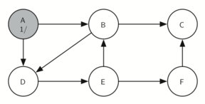

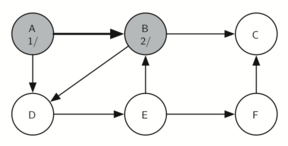

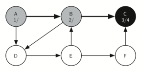

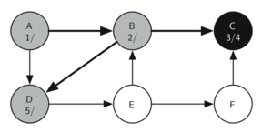

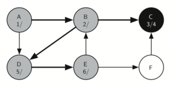

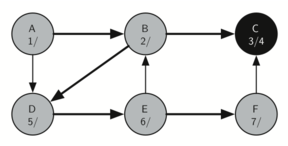

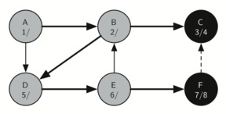

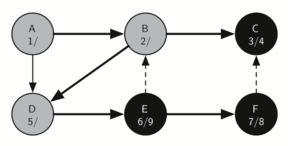

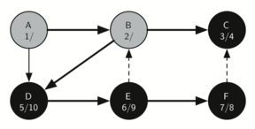

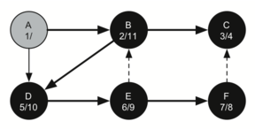

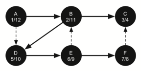

- The starting and finishing times for each node display a property called the parenthesis property.
- This property means that all the children of a particular node in the depth first tree have a later discovery time and an earlier finish time than their parent.

## Implementation of Depth-First Search

This algorithm we will be discussing is Depth-First search which as the name hints at, explores possible vertices (from a supplied root) down each branch before backtracking. This property allows the algorithm to be implemented succinctly in both iterative and recursive forms. Below is a listing of the actions performed upon each visit to a node.

- Mark the current vertex as being visited.
- Explore each adjacent vertex that is not included in the visited set.

We will assume a simplified version of a graph in the following form:

```python
graph = {'A': set(['B', 'C']),
         'B': set(['A', 'D', 'E']),
         'C': set(['A', 'F']),
         'D': set(['B']),
         'E': set(['B', 'F']),
         'F': set(['C', 'E'])}
```

### Connected Component

The implementation below uses the stack data-structure to build-up and return a set of vertices that are accessible within the subjects connected component. Using Python’s overloading of the subtraction operator to remove items from a set, we are able to add only the unvisited adjacent vertices.

```python
def dfs(graph, start):
    visited, stack = set(), [start]
    while stack:
        vertex = stack.pop()
        if vertex not in visited:
            visited.add(vertex)
            stack.extend(graph[vertex] - visited)
    return visited

dfs(graph, 'A')
```

```
{'A', 'B', 'C', 'D', 'E', 'F'}
```

The second implementation provides the same functionality as the first, however, this time we are using the more succinct recursive form. Due to a common Python gotcha with default parameter values being created only once, we are required to create a new visited set on each user invocation. Another Python language detail is that function variables are passed by reference, resulting in the visited mutable set not having to reassigned upon each recursive call.

```python
def dfs(graph, start, visited=None):
    if visited is None:
        visited = set()
    visited.add(start)
    for nxt in graph[start] - visited:
        dfs(graph, nxt, visited)
    return visited

dfs(graph, 'A')
```

```
{'A', 'B', 'C', 'D', 'E', 'F'}
```

### Paths

We are able to tweak both of the previous implementations to return all possible paths between a start and goal vertex. The implementation below uses the stack data-structure again to iteratively solve the problem, yielding each possible path when we locate the goal. Using a generator allows the user to only compute the desired amount of alternative paths.

```python
def dfs_paths(graph, start, goal):
    stack = [(start, [start])]
    while stack:
        (vertex, path) = stack.pop()
        for nxt in graph[vertex] - set(path):
            if nxt == goal:
                yield path + [nxt]
            else:
                stack.append((nxt, path + [nxt]))

list(dfs_paths(graph, 'A', 'F'))
```

```
[['A', 'B', 'E', 'F'], ['A', 'C', 'F']]
```

## Knight's Tour Code

- The knight’s tour puzzle is played on a chess board with a single chess piece, the knight. The object of the puzzle is to find a sequence of moves that allow the knight to visit every square on the board exactly once.
- We will solve the problem using two main steps:
  - Represent the legal moves of a knight on a chessboard as a graph.
  - Use a graph algorithm to find a path of length rows×columns−1 where every vertex on the graph is visited exactly once.
- To represent the knight’s tour problem as a graph we will use the following two ideas:
  - Each square on the chessboard can be represented as a node in the graph.
  - Each legal move by the knight can be represented as an edge in the graph.
- The search algorithm we will use to solve the knight’s tour problem is called depth first search (DFS).
- Whereas the breadth first search algorithm discussed in the previous section builds a search tree one level at a time, a depth first search creates a search tree by exploring one branch of the tree as deeply as possible.
- When the knightTour function is called, it first checks the base case condition.
- If we have a path that contains 64 vertices, we return from knightTour with a status of True, indicating that we have found a successful tour.
- If the path is not long enough we continue to explore one level deeper by choosing a new vertex to explore and calling knightTour recursively for that vertex.
- DFS also uses colors to keep track of which vertices in the graph have been visited.
- Unvisited vertices are colored white, and visited vertices are colored gray.
- If all neighbors of a particular vertex have been explored and we have not yet reached our goal length of 64 vertices, we have reached a dead end.
- If all neighbors of a particular vertex have been explored and we have not yet reached our goal length of 64 vertices, we have reached a dead end.
- When we reach a dead end we must backtrack
- Backtracking happens when we return from knightTour with a status of False.
- In the breadth first search we used a queue to keep track of which vertex to visit next.
- Since depth first search is recursive, we are implicitly using a stack to help us with our backtracking.
- When we return from a call to knightTour with a status of False we remain inside the while loop and look at the next vertex in nbrList.

[figure not shown]

```python
def knightGraph(bdSize):
    ktGraph = Graph()
    for row in range(bdSize):
        for col in range(bdSize):
            nodeId = posToNodeId(row,col,bdSize)
            newPositions = genLegalMoves(row,col,bdSize)
            for e in newPositions:
                nid = posToNodeId(e[0],e[1],bdSize)
                ktGraph.addEdge(nodeId,nid)
    return ktGraph

def posToNodeId(row, column, board_size):
    return (row * board_size) + column
```

```python
def genLegalMoves(x,y,bdSize):
    newMoves = []
    moveOffsets = [(-1,-2),(-1,2),(-2,-1),(-2,1),
                   ( 1,-2),( 1,2),( 2,-1),( 2,1)]
    for i in moveOffsets:
        newX = x + i[0]
        newY = y + i[1]
        if legalCoord(newX,bdSize) and \
                        legalCoord(newY,bdSize):
            newMoves.append((newX,newY))
    return newMoves

def legalCoord(x,bdSize):
    if x >= 0 and x < bdSize:
        return True
    else:
        return False
```

```python
def knightTour(n,path,u,limit):
        u.setColor('gray')
        path.append(u)
        if n < limit:
            nbrList = list(u.getConnections())
            i = 0
            done = False
            while i < len(nbrList) and not done:
                if nbrList[i].getColor() == 'white':
                    done = knightTour(n+1, path, nbrList[i], limit)
                i = i + 1
            if not done:  # prepare to backtrack
                path.pop()
                u.setColor('white')
        else:
            done = True
        return done
```

## Word Ladder Example Code

Consider the following puzzle called a word ladder. Transform the word “FOOL” into the word “SAGE”.In a word ladder puzzle you must make the change occur gradually by changing one letter at a time.At each step you must transform one word into another word, you are not allowed to transform a word into a non-word.

FOOL, POOL, POLL, POLE, PALE, SALE, SAGE

- We can solve this problem using a graph algorithm.
  - Represent the relationships between the words as a graph.
  - Use the graph algorithm known as breadth first search to find an efficient path from the starting word to the ending word.
- Figure out how to turn a large collection of words into a graph.
- What we would like is to have an edge from one word to another if the two words are only different by a single letter.
- Then any path from one word to another is a solution to the word ladder puzzle.

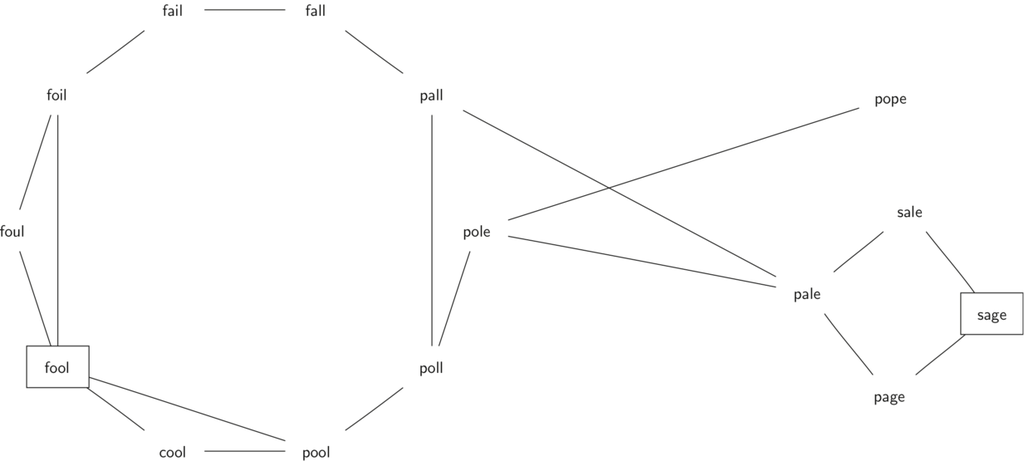

Suppose that we have a huge number of buckets, each of them with a four-letter word on the outside, except that one of the letters in the label has been replaced by an underscore.

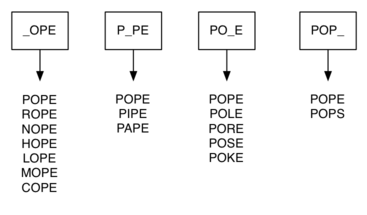

```python
class Vertex:
    def __init__(self,key):
        self.id = key
        self.connectedTo = {}

    def addNeighbor(self,nbr,weight=0):
        self.connectedTo[nbr] = weight

    def __str__(self):
        return str(self.id) + ' connectedTo: ' + str([x.id for x in self.connectedTo])

    def getConnections(self):
        return self.connectedTo.keys()

    def getId(self):
        return self.id

    def getWeight(self,nbr):
        return self.connectedTo[nbr]
```

```python
class Graph:
    def __init__(self):
        self.vertList = {}
        self.numVertices = 0

    def addVertex(self,key):
        self.numVertices = self.numVertices + 1
        newVertex = Vertex(key)
        self.vertList[key] = newVertex
        return newVertex

    def getVertex(self,n):
        if n in self.vertList:
            return self.vertList[n]
        else:
            return None

    def __contains__(self,n):
        return n in self.vertList

    def addEdge(self,f,t,cost=0):
        if f not in self.vertList:
            nv = self.addVertex(f)
        if t not in self.vertList:
            nv = self.addVertex(t)
        self.vertList[f].addNeighbor(self.vertList[t], cost)

    def getVertices(self):
        return self.vertList.keys()

    def __iter__(self):
        return iter(self.vertList.values())
```

Code for buildGraph function:

```python
def buildGraph(wordFile):
    d = {}
    g = Graph()

    wfile = open(wordFile,'r')
    # create buckets of words that differ by one letter
    for line in wfile:
        print line
        word = line[:-1]
        print word
        for i in range(len(word)):
            bucket = word[:i] + '_' + word[i+1:]
            if bucket in d:
                d[bucket].append(word)
            else:
                d[bucket] = [word]
    # add vertices and edges for words in the same bucket
    for bucket in d.keys():
        for word1 in d[bucket]:
            for word2 in d[bucket]:
                if word1 != word2:
                    g.addEdge(word1,word2)
    return g
```

Extra Resource: MIT Algorithms and Data Structure Course! https://www.youtube.com/watch?v=s-CYnVz-uh4